# Assignment 7: Visualization - Some aspects of ggplot2

### II. Questions on Covid Vaccination Data

In this section of questions, we will use the covid vaccination data for the US. The data and data dictionary can be found at the below link:

- [Data](https://raw.githubusercontent.com/govex/COVID-19/master/data_tables/vaccine_data/us_data/time_series/vaccine_data_us_timeline.csv)
- [Data Dictionary](https://github.com/govex/COVID-19/blob/master/data_tables/vaccine_data/us_data/data_dictionary.csv)

```r
library(tidyverse)
df <- read_csv('https://raw.githubusercontent.com/govex/COVID-19/master/data_tables/vaccine_data/us_data/time_series/vaccine_data_us_timeline.csv')
```

1. Put titles, captions, appropriate labels on x and y-axis for the last two questions in Assignments 6.

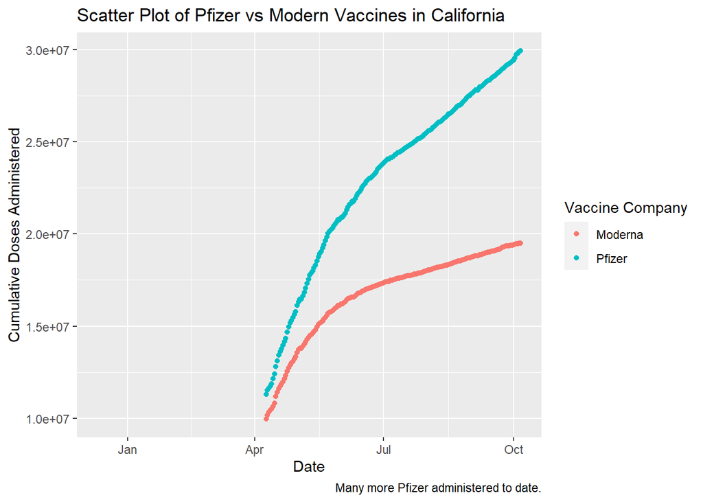

```r
df %>% filter(Province_State=='California') %>% filter(Vaccine_Type==c('Moderna','Pfizer')) %>% ggplot()+geom_point(mapping = aes(x = Date, y = Doses_admin, color = Vaccine_Type)) + labs(x='Date',
       y = 'Cumulative Doses Administered',
       color='Vaccine Company',
       title = 'Scatter Plot of Pfizer vs Modern Vaccines in California',
       caption = 'Many more Pfizer administered to date.')
```

```r
library(lubridate)
```

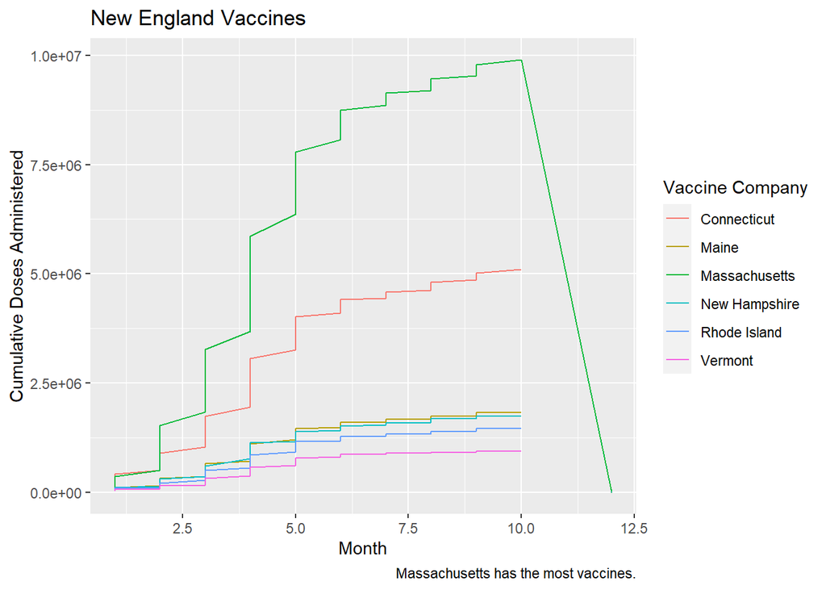

```r
df  %>% filter(Vaccine_Type ==c('All')) %>% filter(Province_State==c('Rhode Island','Maine','Connecticut','New Hampshire','Massachusetts','Vermont')) %>%  group_by(Date, Vaccine_Type, Province_State) %>% summarise(DOSES = mean(Doses_admin)) %>% ggplot()+geom_line(mapping = aes(x = month(Date), y = DOSES, color = Province_State)) + labs(x='Month',
       y = 'Cumulative Doses Administered',
       color='Vaccine Company',
       title = 'New England Vaccines',
       caption = 'Massachusetts has the most vaccines.')
```

```r
#Used one graph from Question 1 on assignment 6 and one graph from Question 2
```

2. Since the data seems lack of categorical variables, we will create a few categorical variables for easier visualization. From the `Date` variable create three categorical variables to record weekdays, months and quarters. You could also create a categorical variable to record the state regions (South, North East, Midwest, West) or other new categorical variables.

```r
df$month = month(df$Date)
df$quarter = quarter(df$Date)
df$weekday = wday(df$Date)
df$weekend <- case_when(
  df$weekday ==1 ~ 1,
  df$weekday ==7 ~ 1,
  TRUE ~ 0)
df$NewEng <- case_when(
  df$Province_State =='Maine' ~ 1,
  df$Province_State =='Massachusetts' ~ 1,
  df$Province_State =='Connecticut' ~ 1,
  df$Province_State =='Rhode Island' ~ 1,
  df$Province_State =='New Hampshire' ~ 1,
  df$Province_State =='Vermont' ~ 1,
  TRUE ~ 0)
```

3. With the updated data after question 2. Create at least 7 new meaningful graphs. Your graphs should have titles, captions, appropriate labels on x and y-axis. You should also make use of the follows.
- geom_point

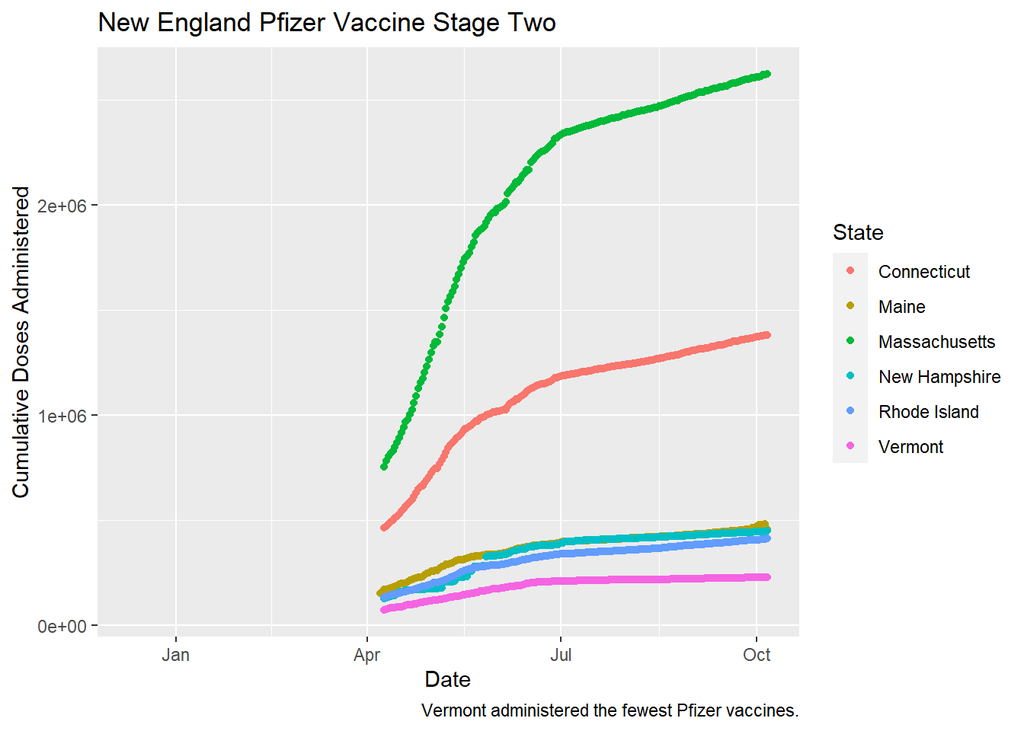

```r
library(tidyverse)
library(ggplot2)
df %>% filter(NewEng==1) %>% filter(Vaccine_Type == 'Pfizer') %>% group_by(Date, Vaccine_Type) %>% ggplot()+geom_point(mapping = aes(x = Date, y = Stage_Two_Doses, color=Province_State)) + labs(x='Date',
       y = 'Cumulative Doses Administered',
       color='State',
       title = 'New England Pfizer Vaccine Stage Two',
       caption = 'Vermont administered the fewest Pfizer vaccines.')
```

- geom_line

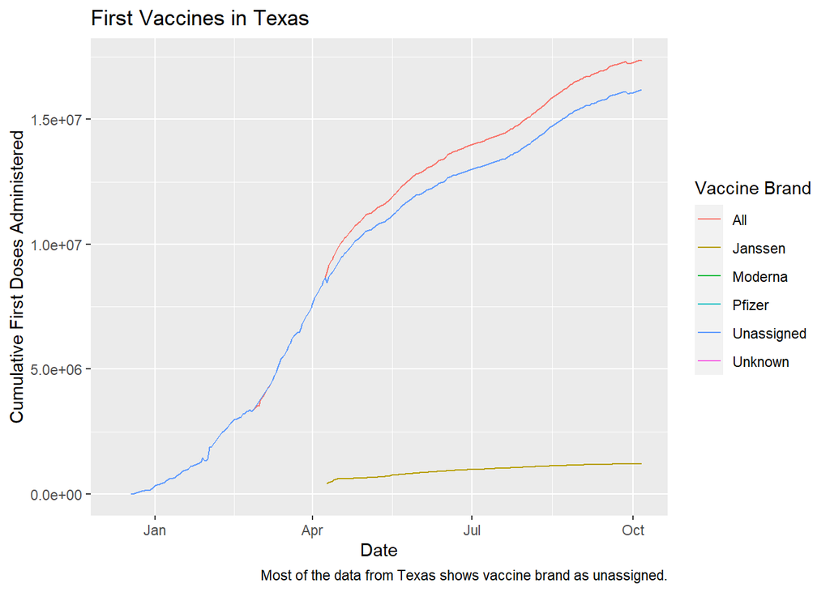

```r
df %>% filter(Province_State =='Texas') %>% group_by(Date, Vaccine_Type) %>% ggplot()+geom_line(mapping = aes(x = Date, y = Stage_One_Doses, color=Vaccine_Type)) + labs(x='Date',
       y = 'Cumulative First Doses Administered',
       color='Vaccine Brand',
       title = 'First Vaccines in Texas',
       caption = 'Most of the data from Texas shows vaccine brand as unassigned.')
```

- geom_smooth

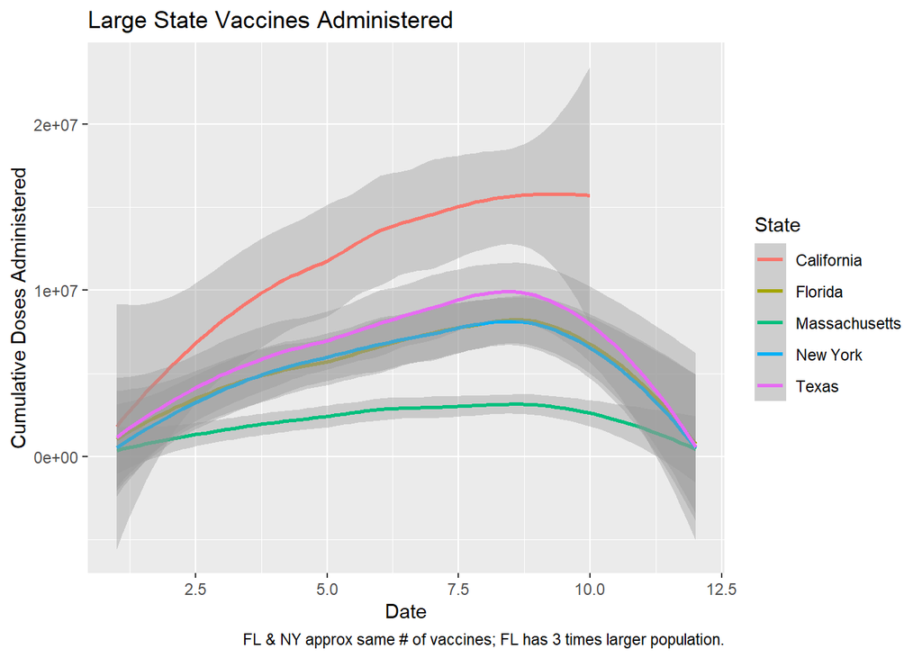

```r
df %>% filter(Province_State==c('California','Florida','New York','Texas','Massachusetts')) %>% group_by(month) %>% ggplot()+geom_smooth(mapping = aes(x = month, y = Doses_admin, color=Province_State)) + labs(x='Date',
       y = 'Cumulative Doses Administered',
       color='State',
       title = 'Large State Vaccines Administered',
       caption = 'FL & NY approx same # of vaccines; FL has 3 times larger population.')
```

_ geom_bar

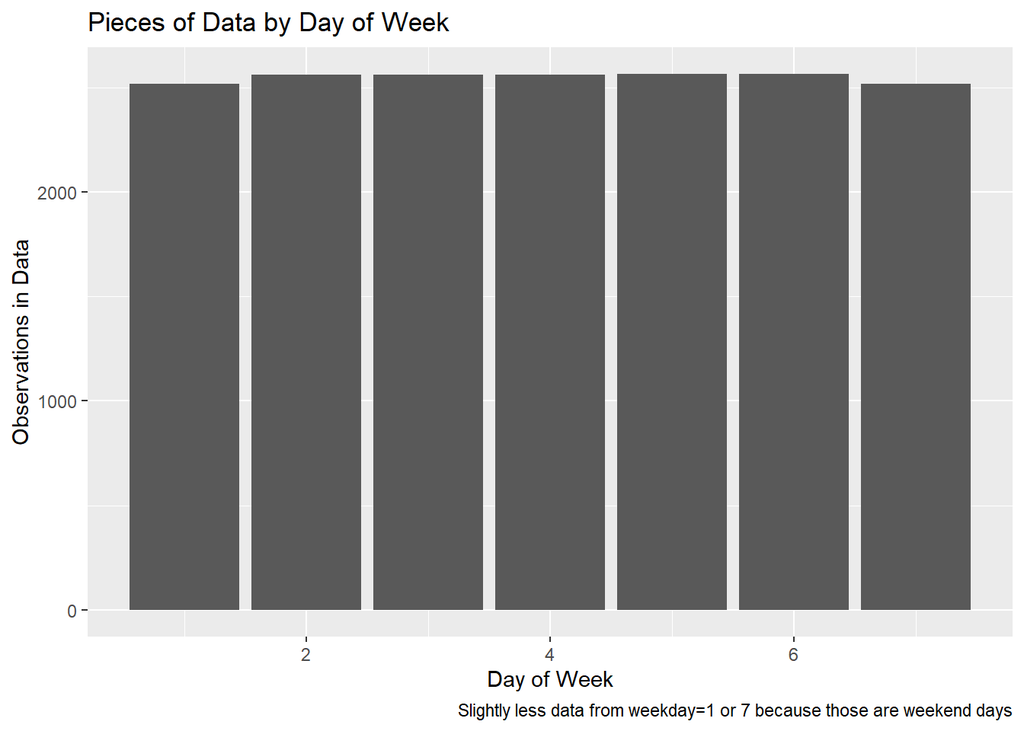

```r
df %>% filter(Vaccine_Type=='Moderna') %>% ggplot()+
  geom_bar(mapping = aes(x = weekday)) + labs(x='Day of Week',
       y = 'Observations in Data',
       title = 'Pieces of Data by Day of Week',
       caption = 'Slightly less data from weekday=1 or 7 because those are weekend days')
```